# exam_2_final

```python
%matplotlib inline
import numpy as np
import pandas as pd
import matplotlib.pyplot as plt
from scipy.stats import norm
from tabulate import tabulate

# Global plot style
plt.rcParams.update({'figure.dpi': 100, 'axes.grid': True,
                     'grid.alpha': 0.3,
                     'axes.spines.top': False, 'axes.spines.right': False})
```

## 1. Introduction

The exercise asks us to perform the following steps:

1. Use the **Euler-Maruyama scheme, Milstein scheme, and the closed-form solution** to simulate the underlying stock price.
2. Compute the option price using the expected value of the discounted payoff under the risk-neutral measure $Q$, i.e.,

$$ V(S,t) = e^{-r(T-t)} \mathbb{E}^Q[\text{payoff}] $$

for **European and binary call options**.

3. Perform a sensitivity analysis to examine the impact of the following parameters on the option price:

   a. Strike price

   b. Time to expiry

   c. Volatility

   d. Risk-free interest rate
4. Examine the antithetic variates variance reduction scheme.

Before we begin implementation and getting results, we'll start off with summary about each stock price simulation scheme which will be used to simulate stock price distribution at expiry. Then we'll discuss two option types and their payoff structures. Sensitivity analysis requires obtaining tools and results hence it will be done after implementation at the results section. Before we move on to implementation we will briefly mention how we can increase accuracy of estimated option price in simulations.

### Euler-Maruyama scheme, Milstein scheme, and the closed-form solution

The exercise focuses on only three stock price simulation schemes. Euler-Maruyama and Milstein schemes simulate the entire stock price path at each time step from initial price to the price and expiration, whereas closed-form solution provides a formula for stock price at its expiration assuming log-normality of stock price. All of the methods assume that stock price has risk-neutral drift rate r instead of $\mu$ which is necessary to calculate option price under risk-neutral probability measure $Q$.

We present all derivations in $ Appendix A$, while here we focus on the final forms of approximate solutions of SDE.

In Euler-Maruyama scheme we approximate solution of SDE by using a discrete version in the form:

$$ S_{t+\delta t} = S_{t} + rS_{t} \delta t + \sigma S_{t} \sqrt{\delta t} \phi $$

where $r$, $\sigma$, $\phi$ and $\delta t$ represent risk-neutral drift per unit of time, volatility per square unit of time, draw from standardized normal distribution and time increment respectively.

In Milstein scheme we approximate solution of SDE by using a discrete version in the form:

$$ S_{t+\delta t} = S_{t}(1 + r \delta t + \sigma \phi \sqrt{\delta t} + \frac{1}{2}\sigma^2(\phi^2-1)\delta t) $$

Note that the local truncation error per step is $O(\delta t^{3/2})$ for Euler-Maruyama and $O(\delta t^{2})$ for Milstein. Accumulated over $1/\delta t$ steps, the global strong convergence order is $O(\delta t^{1/2})$ for Euler-Maruyama and $O(\delta t)$ for Milstein, so Milstein achieves higher accuracy for the same step size. For more details on the derivation please refer to Appendix A.

In exact method we use a discrete version in the form:

$$ S_{t+\delta t} = S_{t} exp((r-\frac{1}{2}\sigma^2)\delta t + \sigma \phi\sqrt{\delta t}) $$

Since both European and Binary options are path-independent and option price can be calculated from stock price distribution at expiration, the closed-form solution will be free from discretization error unlike other two methods. For path-dependent options, the closed-form solution would not be available and numerical approximation schemes like Euler or Milstein should be used. Milstein method will give rise to discretization error which is smaller than in Euler method as it uses more accurate approximation formula. We will discuss the results in more depth in the results section.

### European and Binary options

European and binary options can be distinguished into two types: call and put options. Since in this exercise we focus only on call options, we will introduce only their payoff functions below.

**European Call**

$$ Payoff = max(S_{T}-K, 0) $$

$$C = S\Phi(d_{1}) - K e^{-r(T-t)}\Phi(d_{2})$$

$$\text{Vega} = S \, \Phi'(d_1) \sqrt{T-t}$$

$$\text{Theta} = -\frac{S \, \Phi'(d_1) \sigma}{2\sqrt{T-t}} - r K e^{-r(T-t)} \Phi(d_2) $$

$$\text{Rho} = K (T-t) e^{-r(T-t)} \Phi(d_2)$$

**Binary Call**

$$Payoff = \mathbf{1}_{\{S_{T} > K\}}$$

$$B = e^{-r(T-t)}\Phi(d_{2}) $$

$$\text{Vega} = -e^{-r(T-t)} \Phi'(d_2)\frac{d_1}{\sigma} $$

$$\text{Theta} = e^{-r(T-t)}\left[ r \Phi(d_2) + \Phi'(d_2)\left(\frac{d_1}{2(T-t)} - \frac{r}{\sigma\sqrt{T-t}}\right) \right]$$

$$\text{Rho} = -(T-t) e^{-r(T-t)} \Phi(d_2) + \frac{e^{-r(T-t)} \Phi'(d_2) \sqrt{(T-t)}}{\sigma}$$

Where:

$$d_1 = \frac{\ln(S/K) + \left(r + \frac{\sigma^2}{2}\right)(T-t)}{\sigma\sqrt{T-t}}, \qquad d_2 = d_1 - \sigma\sqrt{T-t}$$

$\Phi'(\cdot)$ is the standard normal PDF, $\Phi(\cdot)$ is the standard normal CDF.

where $K$ and $S_{T}$ denote strike price and stock price at expiration respectively and $S$ denotes stock price at time $t$. In what follows we'll assume $t=0$ and for time to expiry only $T$ will be relevant to us.

In $Appendix B$ we also display charts for Greeks. We'll refer to them in our sensitivity results.

### Simulation error and antithetic variates variance reduction scheme

Stock price simulation in each of the methods above includes $\phi$ term which represents a random draw from standard normal distribution. In all three methods the number of paths is $N$. Option price in each simulation path is a discounted payoff given stock price at expiration. Since option price calculation boils down to average estimation, the resulted Monte-Carlo simulation error (in standard deviation sense) order constitutes $O(N^{-1/2})$.

Antithetic variance scheme makes price estimation more accurate. The idea is based on simulating negatively correlated pairs $\phi$ and $-\phi$, which reduce the variance of the estimator. The antithetic estimator averages the two paired payoffs, so the relevant variance formula is for the mean:

$$\text{Var}\!\left(\frac{X + X_{\text{anti}}}{2}\right) = \frac{1}{4}\left[\text{Var}(X) + \text{Var}(X_{\text{anti}}) + 2\,\text{Cov}(X, X_{\text{anti}})\right]$$

where $X$ denotes the option price estimated from paths using $\phi$ and $X_{\text{anti}}$ from paths using $-\phi$. Since $\text{Var}(X) = \text{Var}(X_{\text{anti}})$ by symmetry, this simplifies to $\frac{1}{2}\left[\text{Var}(X) + \text{Cov}(X, X_{\text{anti}})\right]$. The covariance term is negative because $\phi$ and $-\phi$ are negatively correlated, which is precisely what drives the variance reduction.

The scheme is designed in a following way. For every $\phi_i$, where i denotes path index, we save $\phi_{i}^{anti} = -\phi_i$, so called antithetic variable. Note that $\text{corr}(\phi_i,\, \phi_i^{\text{anti}}) = \text{corr}(\phi_i, -\phi_i) = -1$ by construction. Therefore we synthetically created two negatively correlated stock price paths and payoffs. After taking an average of two options prices computed from antithetic variables we will observe how the total error shrinks due to additional term coming from negative covariance between two variables.

### Implementation

In this section we focus on implementation strategy where we aim to achieve efficient data storage, generation of results, reproduction and validation. We construct a parent class $BSOptionPricer$ where we define key option attributes and analytical price for benchmarking. We also construct a child class $SimulationEngine$ whose purpose is to simulate diffusion term, geometric Brownian motion, calculate option price and generate analytics for given option class instance.

```python
class BSOptionPricer:
    """
    Parent class: Black-Scholes closed-form pricing for European and Binary call options.

    Parameters
    ----------
    S     : float – current spot price
    K     : float – strike price
    T     : float – time to expiry (years)
    sigma : float – annualised volatility
    r     : float – risk-free rate (continuously compounded)
    """

    def __init__(self, S, K, T, sigma, r):
        self.S, self.K, self.T, self.sigma, self.r = S, K, T, sigma, r
        self.d1 = self._d1()
        self.d2 = self._d2()

    def _d1(self):
        return (np.log(self.S / self.K) + (self.r + 0.5 * self.sigma**2) * self.T) / (
            self.sigma * np.sqrt(self.T))

    def _d2(self):
        return self._d1() - self.sigma * np.sqrt(self.T)

    def analytical_european_price(self):
        """Black-Scholes price for a European call option."""
        return (self.S * norm.cdf(self.d1)
                - self.K * np.exp(-self.r * self.T) * norm.cdf(self.d2))

    def analytical_binary_price(self):
        """Black-Scholes price for a cash-or-nothing binary call (pays $1 if S_T > K)."""
        return np.exp(-self.r * self.T) * norm.cdf(self.d2)


class SimulationEngine(BSOptionPricer):
    """
    Child class: Monte Carlo simulation engine for GBM-based option pricing.

    Supports three simulation methods:
      - 'euler'    : Euler-Maruyama first-order approximation
      - 'milstein' : Milstein first-order approximation (adds quadratic correction term)
      - 'exact'    : Closed-form log-normal terminal price (no discretisation error)

    Brownian increments are cached by (T, n_steps, n_paths, seed, antithetic) so that
    different methods and option types share identical noise realisations within an
    experiment, enabling fair method comparisons.

    Parameters
    ----------
    n_steps    : int  – number of time steps per path
    n_paths    : int  – number of Monte Carlo paths
    seed       : int  – random seed (must be int, not None, for error analytics)
    antithetic : bool – if True, mirrors each draw phi -> -phi to reduce variance
    """

    _dw_cache: dict = {}  # class-level cache; call SimulationEngine.clear_cache() to reset

    def __init__(self, S, K, T, sigma, r, n_steps, n_paths, seed=0, antithetic=False):
        super().__init__(S, K, T, sigma, r)
        self.n_steps    = n_steps
        self.n_paths    = n_paths
        self.seed       = seed          # FIX: default 0, not None, so seed+i never raises TypeError
        self.antithetic = antithetic
        self.dt         = self.T / self.n_steps
        self.rng        = np.random.default_rng(seed)
        self.dw         = self._get_or_generate_brownian_increments()

    @classmethod
    def clear_cache(cls):
        """Purge the Brownian increment cache (call between independent experiments)."""
        cls._dw_cache.clear()

    def _get_cache_key(self):
        return (self.T, self.n_steps, self.n_paths, self.seed, self.antithetic)

    def _get_or_generate_brownian_increments(self):
        """
        Generate (or retrieve) scaled Brownian increments dW = phi * sqrt(dt).

        For antithetic sampling, the first half of paths use phi and the second
        half use -phi, keeping the total path count equal to n_paths.
        """
        key = self._get_cache_key()
        if key not in SimulationEngine._dw_cache:
            half = self.n_paths // 2 if self.antithetic else self.n_paths
            phi  = self.rng.standard_normal((half, self.n_steps))
            dw   = np.sqrt(self.dt) * phi
            if self.antithetic:
                dw = np.concatenate([dw, -dw], axis=0)
            SimulationEngine._dw_cache[key] = dw
        return SimulationEngine._dw_cache[key]

    # ── Path simulation ──────────────────────────────────────────────────────

    def simulate_GBM_paths(self, method):
        """
        Simulate GBM stock price paths.

        Returns
        -------
        S_T   : ndarray (n_paths,)           – terminal stock prices
        paths : ndarray (n_paths, n_steps+1) – full price paths (t=0 to T)

        BUG FIX (exact method): original code computed S_T correctly but left
        'paths' as an all-zero array, so plot_paths() would display flat lines.
        Full paths are now reconstructed from cumulative Brownian increments.
        """
        paths       = np.zeros((self.n_paths, self.n_steps + 1))
        paths[:, 0] = self.S   # all methods share the same initial price

        if method == 'exact':
            # Reconstruct full path: S(t) = S0 * exp((r - 0.5*sigma^2)*t + sigma*W(t))
            t_grid  = np.arange(1, self.n_steps + 1) * self.dt   # (n_steps,)
            cum_dw  = np.cumsum(self.dw, axis=1)                  # cumulative W(t)
            paths[:, 1:] = self.S * np.exp(
                (self.r - 0.5 * self.sigma**2) * t_grid[np.newaxis, :]
                + self.sigma * cum_dw)
            S_T = paths[:, -1]

        elif method in ('euler', 'milstein'):
            for t in range(1, self.n_steps + 1):
                S_prev = paths[:, t - 1]
                drift  = self.r * S_prev * self.dt
                diff   = self.sigma * S_prev * self.dw[:, t - 1]
                if method == 'euler':
                    paths[:, t] = S_prev + drift + diff
                else:
                    # Milstein correction: 0.5 * sigma^2 * S * (phi^2 - 1) * dt
                    corr = 0.5 * self.sigma**2 * S_prev * (self.dw[:, t - 1]**2 - self.dt)
                    paths[:, t] = S_prev + drift + diff + corr
            S_T = paths[:, -1]

        else:
            raise ValueError(
                f"Unknown method: '{method}'. Choose 'exact', 'euler', or 'milstein'.")

        return S_T, paths

    def simulate_exact_terminal(self):
        """Return exact log-normal terminal price (benchmark for discretisation error)."""
        W_T = np.sum(self.dw, axis=1)
        return self.S * np.exp(
            (self.r - 0.5 * self.sigma**2) * self.T + self.sigma * W_T)
```

```python
    # ── Pricing ──────────────────────────────────────────────────────────────

    def MC_european_price(self, S_T):
        """Discounted expected payoff max(S_T - K, 0)."""
        payoffs = np.maximum(S_T - self.K, 0)
        if self.antithetic:
            half    = len(payoffs) // 2
            payoffs = 0.5 * (payoffs[:half] + payoffs[half:])
        return np.exp(-self.r * self.T) * np.mean(payoffs)

    def MC_binary_price(self, S_T):
        """Discounted expected payoff 1_{S_T > K}."""
        payoffs = (S_T > self.K).astype(float)
        if self.antithetic:
            half    = len(payoffs) // 2
            payoffs = 0.5 * (payoffs[:half] + payoffs[half:])
        return np.exp(-self.r * self.T) * np.mean(payoffs)

    def get_option_price(self, method, option_type):
        """
        Unified pricing entry point supporting all methods and option types.
        """
        if method == 'analytical':
            if option_type == 'european':
                return self.analytical_european_price()
            elif option_type == 'binary':
                return self.analytical_binary_price()
            else:
                raise ValueError(f"Unknown option_type: '{option_type}'")
        else:
            S_T, _ = self.simulate_GBM_paths(method)
            fn = self.MC_european_price if option_type == 'european' else self.MC_binary_price
            return fn(S_T)

    # ── Analytics ────────────────────────────────────────────────────────────

    def produce_option_price_analytics(self, methods, option_type):
        """
        Print comparison table of prices across all methods, and plot sample GBM paths.

        BUG FIX: original duplicated the simulation inside the loop and called
        MC_european_price regardless of option_type. Now routes everything through
        get_option_price() which handles both option types consistently.
        """
        rows = []
        for method in methods:
            price = self.get_option_price(method, option_type)
            rows.append([method, price])
            # Plot paths for numerical methods in standard (non-antithetic) mode
            if method not in ('analytical', 'exact') and not self.antithetic:
                _, paths = self.simulate_GBM_paths(method)
                self.plot_paths(paths, method, option_type)

        res = pd.DataFrame(rows, columns=['Method', 'Price'])
        print(f"\n{option_type.upper()} Option Prices\n")
        print(tabulate(res, headers='keys', tablefmt='fancy_grid',
                       showindex=False, floatfmt='.6f'))

    def sensitivity_analytics(self, param_name, param_values, option_type, methods):
        """
        Compute and plot option price sensitivity to a single parameter.

        BUG FIX: sorting was hardcoded to prices['analytical'].keys(), which crashes
        if 'analytical' is absent. Now uses the first method in the list.
        """
        prices = {method: {} for method in methods}

        for val in param_values:
            pricer = self._create_pricer_with_param(param_name, val)
            for method in methods:
                prices[method][val] = pricer.get_option_price(method, option_type)

        ref_key     = methods[0]
        sorted_vals = sorted(prices[ref_key].keys())
        table_data  = [{param_name: round(v, 4),
                        **{m: prices[m][v] for m in methods}} for v in sorted_vals]

        price_df = pd.DataFrame(table_data)
        print(f"\n{option_type.upper()} Option Price Sensitivity to {param_name}\n")
        print(tabulate(price_df, headers='keys', tablefmt='fancy_grid',
                       showindex=False, floatfmt='.6f'))

        plt.figure(figsize=(6, 3.5))
        for method in methods:
            plt.plot(sorted_vals, [prices[method][v] for v in sorted_vals],
                     marker='o', label=method, linewidth=2)
        plt.xlabel(param_name, fontsize=12)
        plt.ylabel('Option Price', fontsize=12)
        plt.title(f'Option Price vs {param_name}  [{option_type.upper()}]', fontsize=13)
        plt.legend()
        plt.tight_layout()
        plt.show()

    def _create_pricer_with_param(self, param_name, param_value):
        """Instantiate a new SimulationEngine with one parameter overridden."""
        params = dict(S=self.S, K=self.K, T=self.T, sigma=self.sigma, r=self.r,
                      n_steps=self.n_steps, n_paths=self.n_paths,
                      seed=self.seed, antithetic=self.antithetic)
        params[param_name] = param_value
        return SimulationEngine(**params)

    def error_analytics(self, option_type, methods, n_paths_list, M=10):
        """
        Compute MC variance and bias across multiple path counts over M replications.
        """
        price_truth = (self.analytical_european_price()
                       if option_type == 'european'
                       else self.analytical_binary_price())

        mc_var, bias, stderr = {}, {}, {}

        for n_paths in n_paths_list:
            price = {method: np.zeros(M) for method in methods}
            for i in range(M):
                pricer = SimulationEngine(self.S, self.K, self.T, self.sigma, self.r,
                                          self.n_steps, n_paths,
                                          seed=self.seed + i,  # seed always int: no TypeError
                                          antithetic=self.antithetic)
                for method in methods:
                    price[method][i] = pricer.get_option_price(method, option_type)

            mc_var[n_paths] = {m: np.var(price[m], ddof=1)  for m in methods}
            bias[n_paths]   = {m: np.mean(price[m]) - price_truth for m in methods}
            stderr[n_paths] = {m: 2 * np.std(price[m], ddof=1) / np.sqrt(M) for m in methods}

        print(f"\nMonte Carlo VARIANCE -- {option_type.upper()}\n")
        print(tabulate(pd.DataFrame(mc_var).T, headers='keys',
                       tablefmt='fancy_grid', showindex=True, floatfmt='.8f'))
        self.plot_errors(mc_var, 'Variance', x_label='Number of Paths')
```

```python
        print(f"\nMonte Carlo BIAS -- {option_type.upper()}\n")
        print(tabulate(pd.DataFrame(bias).T, headers='keys',
                       tablefmt='fancy_grid', showindex=True, floatfmt='.8f'))
        self.plot_bias_with_stderr(bias, stderr, option_type)

    def antithetic_variance_reduction_analytics(self, option_types, methods, n_paths_list, M=10):
        """
        Compare MC variance and bias with vs without antithetic variates.
        """
        for option_type in option_types:
            price_truth = (self.analytical_european_price()
                           if option_type == 'european'
                           else self.analytical_binary_price())
            rows = []

            for n_paths in n_paths_list:
                row = {'n_paths': n_paths}
                for antithetic in [False, True]:
                    estimates = {m: np.zeros(M) for m in methods}
                    for i in range(M):
                        pricer = SimulationEngine(self.S, self.K, self.T, self.sigma, self.r,
                                                  self.n_steps, n_paths,
                                                  seed=self.seed + i,
                                                  antithetic=antithetic)
                        for m in methods:
                            estimates[m][i] = pricer.get_option_price(m, option_type)
                    label = 'antithetic' if antithetic else 'standard'
                    for m in methods:
                        row[f'{m}_{label}_var']  = np.var(estimates[m], ddof=1)
                        row[f'{m}_{label}_bias'] = np.mean(estimates[m]) - price_truth
                rows.append(row)

            df = pd.DataFrame(rows)
            self._plot_variance_reduction(df, methods, option_type)

    def _plot_variance_reduction(self, df, methods, option_type):
        """Side-by-side variance: standard vs antithetic, one subplot per method."""
        fig, axes = plt.subplots(1, len(methods), figsize=(5 * len(methods), 3.5), sharey=False)
        if len(methods) == 1:
            axes = [axes]

        for ax, method in zip(axes, methods):
            ax.plot(df['n_paths'], df[f'{method}_standard_var'],
                    marker='o', label='Standard', linewidth=2)
            ax.plot(df['n_paths'], df[f'{method}_antithetic_var'],
                    marker='s', label='Antithetic', linewidth=2, linestyle='--')
            ax.set_title(method.capitalize(), fontsize=12)
            ax.set_xlabel('Number of Paths', fontsize=11)
            ax.set_ylabel('Variance', fontsize=11)
            ax.legend()

        fig.suptitle(
            f'Variance Reduction: Standard vs Antithetic -- {option_type.upper()}', fontsize=13)
        plt.tight_layout()
        plt.show()

    def discretization_error_analytics(self, methods, n_steps_list, M=10):
        """
        Compute RMSE of Euler/Milstein vs exact terminal price across time-step counts.
        """
        total_error = {method: {} for method in methods}

        for n_steps in n_steps_list:
            errors = {method: np.zeros(M) for method in methods}
            for i in range(M):
                pricer = SimulationEngine(self.S, self.K, self.T, self.sigma, self.r,
                                          n_steps, self.n_paths,
                                          seed=self.seed + i,
                                          antithetic=self.antithetic)
                S_exact = pricer.simulate_exact_terminal()
                for method in methods:
                    S_T, _ = pricer.simulate_GBM_paths(method)
                    errors[method][i] = np.sqrt(np.mean((S_T - S_exact)**2))
            for method in methods:
                total_error[method][n_steps] = np.mean(errors[method])

        print('\nDiscretisation RMSE vs Exact Terminal Price\n')
        print(tabulate(pd.DataFrame(total_error), headers='keys',
                       tablefmt='fancy_grid', showindex=True, floatfmt='.4f'))
        # FIX: correct x-axis label for discretisation context
        self.plot_errors(total_error, 'Discretisation RMSE', x_label='Number of Steps')

    # ── Static plot helpers ──────────────────────────────────────────────────

    @staticmethod
    def plot_errors(errors, error_type='Error', x_label='Number of Paths'):
        """
        Line plot of a scalar metric vs the outer dict key.

        BUG FIX: added x_label parameter — original always labelled x-axis
        'Number of Paths', which was incorrect when called from
        discretization_error_analytics (where x is number of steps).
        """
        plt.figure(figsize=(6, 3.5))
        for method, data in errors.items():
            xs = sorted(data.keys())
            plt.plot(xs, [data[x] for x in xs], marker='o', label=method, linewidth=2)
        plt.xlabel(x_label, fontsize=12)
        plt.ylabel(error_type, fontsize=12)
        plt.title(f'Monte Carlo {error_type} vs {x_label}', fontsize=13)
        plt.legend()
        plt.tight_layout()
        plt.show()

    @staticmethod
    def plot_bias_with_stderr(bias, stderr, option_type):
        """Bias plot with shaded +/-2 std-error bands per method."""
        plt.figure(figsize=(6, 3.5))
        methods = sorted(next(iter(bias.values())).keys())
        m_bias  = {m: {} for m in methods}
        m_se    = {m: {} for m in methods}

        for n_paths, data in bias.items():
            for m in methods:
                m_bias[m][n_paths] = data[m]
                m_se[m][n_paths]   = stderr[n_paths][m]

        for m in methods:
            xs      = sorted(m_bias[m].keys())
            b_vals  = np.array([m_bias[m][x] for x in xs])
            se_vals = np.array([m_se[m][x]   for x in xs])
            line    = plt.plot(xs, b_vals, marker='o', label=m, linewidth=2)[0]
            col     = line.get_color()
            plt.fill_between(xs, b_vals - se_vals, b_vals + se_vals, alpha=0.15, color=col)
            plt.plot(xs, b_vals + se_vals, linestyle='--', color=col, linewidth=0.8)
            plt.plot(xs, b_vals - se_vals, linestyle='--', color=col, linewidth=0.8)
```

```python
        plt.axhline(0, color='black', linestyle=':', linewidth=1)
        plt.xlabel('Number of Paths', fontsize=12)
        plt.ylabel('Bias', fontsize=12)
        plt.title(f'Monte Carlo Bias vs Number of Paths -- {option_type.upper()}', fontsize=13)
        plt.legend()
        plt.tight_layout()
        plt.show()

    @staticmethod
    def plot_paths(paths, method, option_type, n_sample=100):
        """Plot the first n_sample GBM price paths.

        Uses paths[:n_sample] rather than a random subsample so that the same
        underlying paths array always produces the same chart — important because
        European and binary options share identical GBM paths (same seed) and
        should display identically here.
        """
        plt.figure(figsize=(6, 3.5))
        n = min(n_sample, len(paths))
        for i in range(n):
            plt.plot(paths[i], lw=0.4, alpha=0.7)
        plt.title(f'GBM Paths -- {option_type.upper()} -- {method}', fontsize=12)
        plt.xlabel('Time Steps', fontsize=11)
        plt.ylabel('Stock Price', fontsize=11)
        plt.tight_layout()
        plt.show()
```

Two functions below will be used to run sensitivity and error analytics

```python
# ── helpers ──────────────────────────────────────────────────────────────────

def run_sensitivity_analysis(pricer, sensitivity_params, option_types, methods):
    for param_name, param_range in sensitivity_params.items():
        for option_type in option_types:
            pricer.sensitivity_analytics(param_name, param_range, option_type, methods)


def run_error_analytics(pricer, option_types, methods, n_paths_list, M=10):
    mc_methods = [m for m in methods if m != 'analytical']
    for option_type in option_types:
        pricer.error_analytics(option_type, mc_methods, n_paths_list, M)
```

## 2. Results

We'll now initialize B-S option pricer with given sample data, generate tables comparing analytical price against price computed via Monte-Carlo simulations for each option type and simulation method. To compare results across three methods we need to fix random seed to match diffusion term in Euler and Milstein schemes and in addition we need to couple these two processes with closed-form solution by representing total diffusion term in exact method as a sum of all incremental noises.

```python
S, K, T, sigma, r = 100, 100, 1, 0.2, 0.05 # sample data
n_steps, n_paths, seed = 252, 5000, 0 # length of time grid, number of simulation paths, random seed
methods      = ['analytical', 'exact', 'euler', 'milstein']
option_types = ['european', 'binary']
n_paths_list = [100, 500, 1000, 5000] # number of paths used in error analysis
n_steps_list = [1, 2, 4, 8, 16, 32, 64, 128, 252, 500]
M            = 50 # number of simulation repetitions for bias calculation

# grids of parameters for sensitivity analysis
sensitivity_params = {
    "K":     [K     * s for s in [0.9, 1.0, 1.1]],
    "sigma": [sigma * s for s in [0.8, 1.0, 1.2]],
    "T":     [T     * s for s in [0.8, 1.0, 1.2]],
    "r":     [r     * s for s in [0.8, 1.0, 1.2]],
}
```

Below we perform stock price simulations for each method and compare price. For now we can only state that simulated paths exhibit typical drift and diffusion behavior and estimated results are close to the benchmark. However, in next sections we'll dive into deeper analysis.

```
================================================================================
BASE OPTION PRICES - STANDARD
================================================================================
```

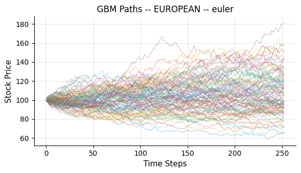

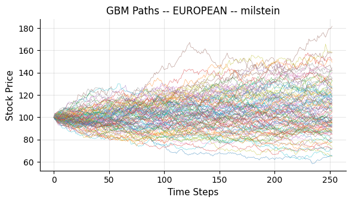

```
EUROPEAN Option Prices

╒════════════╤═══════════╕
│ Method     │     Price │
╞════════════╪═══════════╡
│ analytical │ 10.450584 │
├────────────┼───────────┤
│ exact      │ 10.549578 │
├────────────┼───────────┤
│ euler      │ 10.546557 │
├────────────┼───────────┤
│ milstein   │ 10.547764 │
╘════════════╧═══════════╛
```

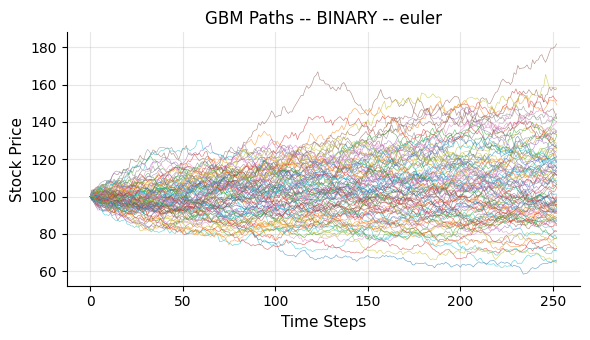

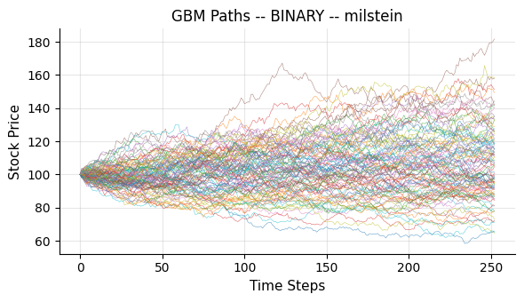

```
BINARY Option Prices

╒════════════╤══════════╕
│ Method     │    Price │
╞════════════╪══════════╡
│ analytical │ 0.532325 │
├────────────┼──────────┤
│ exact      │ 0.534591 │
├────────────┼──────────┤
│ euler      │ 0.534781 │
├────────────┼──────────┤
│ milstein   │ 0.534591 │
╘════════════╧══════════╛
```

```python
# ── standard pricer ──────────────────────────────────────────────────────
pricer = SimulationEngine(S, K, T, sigma, r, n_steps, n_paths, seed=seed, antithetic=False)

print("=" * 80)
print("BASE OPTION PRICES - STANDARD")
print("=" * 80)
for option_type in option_types:
    pricer.produce_option_price_analytics(methods, option_type)
```

In the next section we perform sensitivity analysis where we display the impact of varying parameters on option prices. We'll focus on the impact of strike $K$, volatility $\sigma$, time to maturity $T$ and risk-free rate $r$.

$\textbf{Sensitivity to K}$

We observe that European and binary call options are costly for lower strikes which is expected as they are more in-the-money and have higher intrinsic value.

$\textbf{Sensitivity to}$ $\sigma$

Volatility does not have trivial effect on prices like $K$ on two option types.

European options are more expensive when the stock price is more volatile, and the direction doesn't depend on option moneyness (only magnitude does). Call option has limited downside and unlimited upside and this asymmetry in the payoff function results in positive effect of volatility.

Vega peaks at ATM because it carries downside protection with upside participation. However, when it's either deep OTM or ITM the option is likely to expire worthless or will be exercised, so vega will be smaller.

On the contrary, the effect of volatility on binary call option price (Vega) is ambiguous and depends on option moneyness. When a binary call is deep OTM, higher volatility increases the chance of finishing ITM — so the option gains value with vol, making vega positive. When spot price is almost $0$ option price is almost immune to its volatility as probability of ending up ITM is almost $0$.

Moving from OTM to ATM vega peaks and then turns negative — extra vol makes the payoff uncertain (it might finish either side), so the binary loses value.

In Deep ITM region vol hurts - vega is negative as a near-certain payout is eroded by vol pushing it back below $K$

In our exercise, we consider ATM option, and we can notice decay in option price when we increase sigma.

$\textbf{Sensitivity to T}$

For a European call, a longer time to expiry increases the option's value ($\partial C / \partial T > 0$): more time means a higher chance of a favourable move and greater discounting of the strike. In the sensitivity grid we therefore see prices rising with $T$, which is consistent with a positive time-value effect. Note this is distinct from Theta ($\partial C / \partial t < 0$), which measures the price decay as calendar time $t$ passes (i.e. as $T-t$ shrinks). Theta is most negative at-the-money because time value is largest there — the option carries meaningful downside protection alongside upside participation.

When the option is deep OTM it is likely to expire worthless so time value is small. Similarly, when deep ITM the option behaves like a forward and time value is again low.

Unlike European, binary theta changes the sign depending on moneyness and the point where it changes it depends on the interplay between $\rho$ and $\sigma$.

When the binary is deep OTM it needs to wait until big jump in stock price happens to be ITM and the more time passes the less worthy binary is. Here, discounting is dominated by distribution term.

On the other hand, when the binary is deep ITM, it's likely to be exercised and the more time passes the less discounting will be applied to its payout. Here, discounting beats distribution term.

Near ATM region, discounting and distribution terms compete and the crossover point is determined by relationship between $r$ and $\sigma$.

$\textbf{Sensitivity to r}$

For European option rho is always positive due to higher forward price and its magnitude only depends on moneyness.

In binary option two terms actively compete and rho sign is driven by option moneyness. In deep ITM region discounting term pulls option value down, while in OTM and ATM regions higher $r$ increases forward price and the chances of option exercise.

In our example, option is ATM and thus rho stays positive for two options.

```
================================================================================
SENSITIVITY ANALYSIS
================================================================================

EUROPEAN Option Price Sensitivity to K

╒════════════╤══════════════╤═══════════╤═══════════╤════════════╕
│          K │   analytical │     exact │     euler │   milstein │
╞════════════╪══════════════╪═══════════╪═══════════╪════════════╡
│  90.000000 │    16.699448 │ 16.838195 │ 16.838492 │  16.836701 │
├────────────┼──────────────┼───────────┼───────────┼────────────┤
│ 100.000000 │    10.450584 │ 10.549578 │ 10.546557 │  10.547764 │
├────────────┼──────────────┼───────────┼───────────┼────────────┤
│ 110.000000 │     6.040088 │  6.102479 │  6.098621 │   6.100673 │
╘════════════╧══════════════╧═══════════╧═══════════╧════════════╛
```

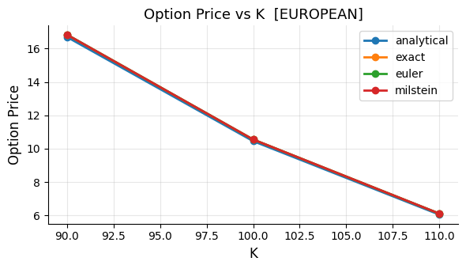

```
BINARY Option Price Sensitivity to K

╒════════════╤══════════════╤══════════╤══════════╤════════════╕
│          K │   analytical │    exact │    euler │   milstein │
╞════════════╪══════════════╪══════════╪══════════╪════════════╡
│  90.000000 │     0.714121 │ 0.720081 │ 0.719510 │   0.720081 │
├────────────┼──────────────┼──────────┼──────────┼────────────┤
│ 100.000000 │     0.532325 │ 0.534591 │ 0.534781 │   0.534591 │
├────────────┼──────────────┼──────────┼──────────┼────────────┤
│ 110.000000 │     0.353861 │ 0.357853 │ 0.358043 │   0.357853 │
╘════════════╧══════════════╧══════════╧══════════╧════════════╛
```

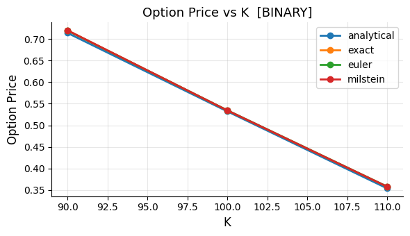

```
EUROPEAN Option Price Sensitivity to sigma

╒══════════╤══════════════╤═══════════╤═══════════╤════════════╕
│    sigma │   analytical │     exact │     euler │   milstein │
╞══════════╪══════════════╪═══════════╪═══════════╪════════════╡
│ 0.160000 │     8.959897 │  9.038391 │  9.036401 │   9.036885 │
├──────────┼──────────────┼───────────┼───────────┼────────────┤
│ 0.200000 │    10.450584 │ 10.549578 │ 10.546557 │  10.547764 │
├──────────┼──────────────┼───────────┼───────────┼────────────┤
│ 0.240000 │    11.957778 │ 12.078787 │ 12.074895 │  12.076670 │
╘══════════╧══════════════╧═══════════╧═══════════╧════════════╛
```

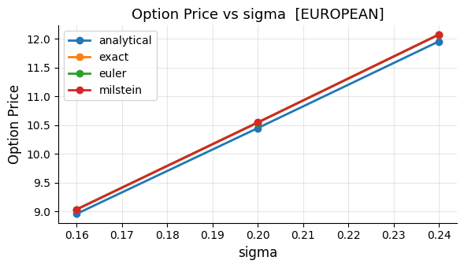

```
BINARY Option Price Sensitivity to sigma

╒══════════╤══════════════╤══════════╤══════════╤════════════╕
│    sigma │   analytical │    exact │    euler │   milstein │
╞══════════╪══════════════╪══════════╪══════════╪════════════╡
│ 0.160000 │     0.563057 │ 0.563318 │ 0.564460 │   0.563318 │
├──────────┼──────────────┼──────────┼──────────┼────────────┤
│ 0.200000 │     0.532325 │ 0.534591 │ 0.534781 │   0.534591 │
├──────────┼──────────────┼──────────┼──────────┼────────────┤
│ 0.240000 │     0.509092 │ 0.510620 │ 0.511381 │   0.510620 │
╘══════════╧══════════════╧══════════╧══════════╧════════════╛
```

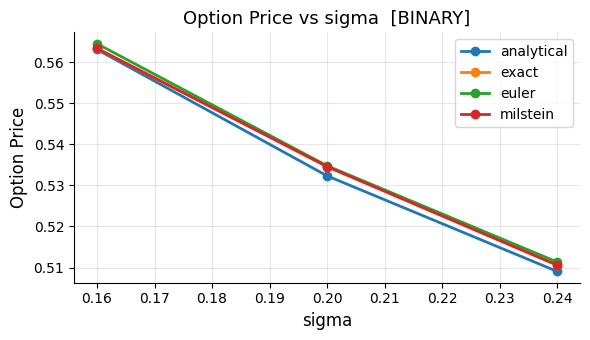

```
EUROPEAN Option Price Sensitivity to T

╒══════════╤══════════════╤═══════════╤═══════════╤════════════╕
│        T │   analytical │     exact │     euler │   milstein │
╞══════════╪══════════════╪═══════════╪═══════════╪════════════╡
│ 0.800000 │     9.121259 │  9.207225 │  9.204742 │   9.205944 │
├──────────┼──────────────┼───────────┼───────────┼────────────┤
│ 1.000000 │    10.450584 │ 10.549578 │ 10.546557 │  10.547764 │
├──────────┼──────────────┼───────────┼───────────┼────────────┤
│ 1.200000 │    11.694956 │ 11.806216 │ 11.802545 │  11.803809 │
╘══════════╧══════════════╧═══════════╧═══════════╧════════════╛
```

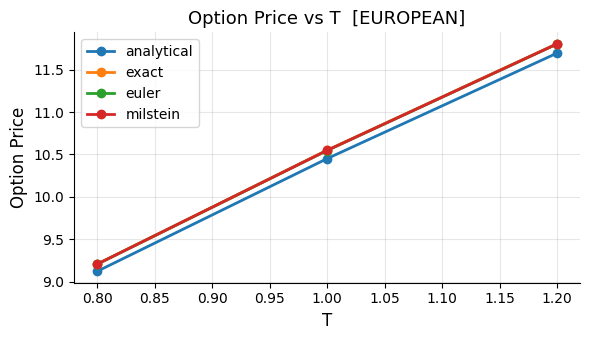

```
BINARY Option Price Sensitivity to T

╒══════════╤══════════════╤══════════╤══════════╤════════════╕
│        T │   analytical │    exact │    euler │   milstein │
╞══════════╪══════════════╪══════════╪══════════╪════════════╡
│ 0.800000 │     0.531666 │ 0.534583 │ 0.534391 │   0.534583 │
├──────────┼──────────────┼──────────┼──────────┼────────────┤
│ 1.000000 │     0.532325 │ 0.534591 │ 0.534781 │   0.534591 │
├──────────┼──────────────┼──────────┼──────────┼────────────┤
│ 1.200000 │     0.532341 │ 0.534546 │ 0.535487 │   0.534546 │
╘══════════╧══════════════╧══════════╧══════════╧════════════╛
```

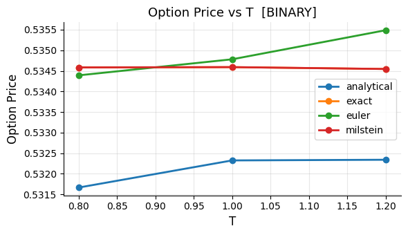

```
EUROPEAN Option Price Sensitivity to r

╒══════════╤══════════════╤═══════════╤═══════════╤════════════╕
│        r │   analytical │     exact │     euler │   milstein │
╞══════════╪══════════════╪═══════════╪═══════════╪════════════╡
│ 0.040000 │     9.925054 │ 10.022033 │ 10.019281 │  10.020620 │
├──────────┼──────────────┼───────────┼───────────┼────────────┤
│ 0.050000 │    10.450584 │ 10.549578 │ 10.546557 │  10.547764 │
├──────────┼──────────────┼───────────┼───────────┼────────────┤
│ 0.060000 │    10.989549 │ 11.090995 │ 11.087891 │  11.088761 │
╘══════════╧══════════════╧═══════════╧═══════════╧════════════╛
```

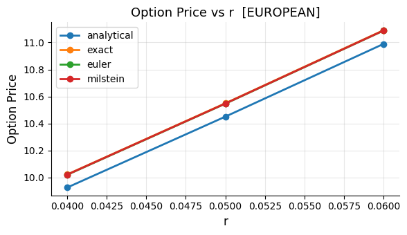

```
BINARY Option Price Sensitivity to r

╒══════════╤══════════════╤══════════╤══════════╤════════════╕
│        r │   analytical │    exact │    euler │   milstein │
╞══════════╪══════════════╪══════════╪══════════╪════════════╡
│ 0.040000 │     0.518661 │ 0.519595 │ 0.519595 │   0.519595 │
├──────────┼──────────────┼──────────┼──────────┼────────────┤
│ 0.050000 │     0.532325 │ 0.534591 │ 0.534781 │   0.534591 │
├──────────┼──────────────┼──────────┼──────────┼────────────┤
│ 0.060000 │     0.545526 │ 0.546600 │ 0.547165 │   0.546600 │
╘══════════╧══════════════╧══════════╧══════════╧════════════╛
```

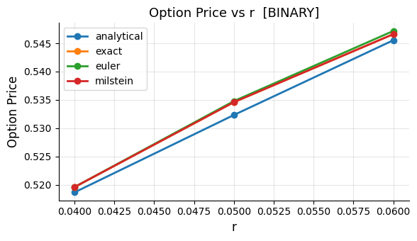

```python
print("\n" + "=" * 80)
print("SENSITIVITY ANALYSIS")
print("=" * 80)
run_sensitivity_analysis(pricer, sensitivity_params, option_types, methods)
```

#### Error analysis for European option

Clearly, our previous summary of methods needs to be further supported with error analysis as the results only demonstrates point estimates and does not show:

1. MC error if we vary the number of simulation paths
2. Bias if we repeat simulations many times and produce M point estimates

In this section let's produce error analysis for each option type separately. We'll examine MC error, simulation bias and conclude with discretization error.

After that we'll introduce antithetic variates control scheme, update error results and discuss its impact.

```
================================================================================
ERROR ANALYTICS - STANDARD
================================================================================

Monte Carlo VARIANCE -- EUROPEAN

╒══════╤════════════╤════════════╤════════════╕
│      │      exact │      euler │   milstein │
╞══════╪════════════╪════════════╪════════════╡
│  100 │ 2.44732733 │ 2.44276471 │ 2.44634728 │
├──────┼────────────┼────────────┼────────────┤
│  500 │ 0.37521466 │ 0.37634956 │ 0.37505895 │
├──────┼────────────┼────────────┼────────────┤
│ 1000 │ 0.17222945 │ 0.17188651 │ 0.17215557 │
├──────┼────────────┼────────────┼────────────┤
│ 5000 │ 0.03896076 │ 0.03905042 │ 0.03894229 │
╘══════╧════════════╧════════════╧════════════╛
```

[figure not shown]

```
Monte Carlo BIAS -- EUROPEAN

╒══════╤════════════╤════════════╤════════════╕
│      │      exact │      euler │   milstein │
╞══════╪════════════╪════════════╪════════════╡
│  100 │ 0.22569740 │ 0.22673992 │ 0.22384731 │
├──────┼────────────┼────────────┼────────────┤
│  500 │ 0.03966503 │ 0.04037957 │ 0.03785273 │
├──────┼────────────┼────────────┼────────────┤
│ 1000 │ 0.01077618 │ 0.01062089 │ 0.00896985 │
├──────┼────────────┼────────────┼────────────┤
│ 5000 │ 0.02088148 │ 0.02062095 │ 0.01907396 │
╘══════╧════════════╧════════════╧════════════╛
```

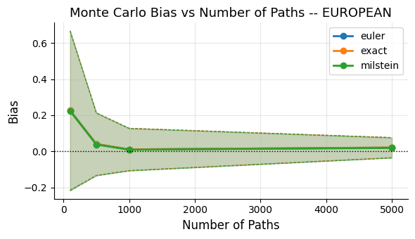

```
Monte Carlo VARIANCE -- BINARY

╒══════╤════════════╤════════════╤════════════╕
│      │      exact │      euler │   milstein │
╞══════╪════════════╪════════════╪════════════╡
│  100 │ 0.00190939 │ 0.00191441 │ 0.00190939 │
├──────┼────────────┼────────────┼────────────┤
│  500 │ 0.00036310 │ 0.00037391 │ 0.00036328 │
├──────┼────────────┼────────────┼────────────┤
│ 1000 │ 0.00019160 │ 0.00019413 │ 0.00019162 │
├──────┼────────────┼────────────┼────────────┤
│ 5000 │ 0.00003836 │ 0.00003842 │ 0.00003832 │
╘══════╧════════════╧════════════╧════════════╛
```

[figure not shown]

```
Monte Carlo BIAS -- BINARY

╒══════╤═════════════╤═════════════╤═════════════╕
│      │       exact │       euler │    milstein │
╞══════╪═════════════╪═════════════╪═════════════╡
│  100 │ -0.00153880 │ -0.00115830 │ -0.00153880 │
├──────┼─────────────┼─────────────┼─────────────┤
│  500 │ -0.00271832 │ -0.00207149 │ -0.00264222 │
├──────┼─────────────┼─────────────┼─────────────┤
│ 1000 │ -0.00190026 │ -0.00155782 │ -0.00184319 │
├──────┼─────────────┼─────────────┼─────────────┤
│ 5000 │ -0.00116972 │ -0.00108982 │ -0.00114309 │
╘══════╧═════════════╧═════════════╧═════════════╛
```

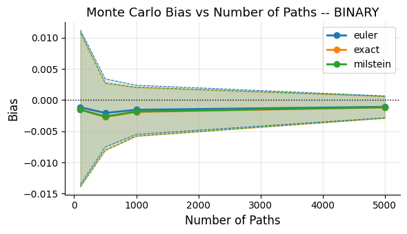

```python
print("\n" + "=" * 80)
print("ERROR ANALYTICS - STANDARD")
print("=" * 80)
run_error_analytics(pricer, option_types, methods, n_paths_list, M)
```

As discussed in the introduction section, Milstein and Euler schemes are only first order approximations of SDE where Milstein employs more accurate approximation formula than Euler. In contrast, exact method does not carry discretization error as it generates terminal $S_T$ using closed-form formula whereas any approximation of the exact formula will inevitably lead to the difference $S_T^{exact} - S_T^{Milstein, Euler}$.

To show the impact of time grid size on discretization error we vary the number of time increments and observe the finer our grid is the more Euler converges to Milstein. This is consistent with the global strong convergence orders: $O(\delta t^{1/2})$ for Euler and $O(\delta t)$ for Milstein, so both errors shrink as the grid is refined, with Milstein remaining more accurate for any given step size.

```
================================================================================
DISCRETIZATION ERROR ANALYTICS
================================================================================

Discretisation RMSE vs Exact Terminal Price

╒═════╤═════════╤═════════╤════════════╕
│     │   exact │   euler │   milstein │
╞═════╪═════════╪═════════╪════════════╡
│   1 │  0.0000 │  3.1645 │     1.0984 │
├─────┼─────────┼─────────┼────────────┤
│   2 │  0.0000 │  2.1882 │     0.5674 │
├─────┼─────────┼─────────┼────────────┤
│   4 │  0.0000 │  1.5357 │     0.2898 │
├─────┼─────────┼─────────┼────────────┤
│   8 │  0.0000 │  1.0811 │     0.1464 │
├─────┼─────────┼─────────┼────────────┤
│  16 │  0.0000 │  0.7598 │     0.0733 │
├─────┼─────────┼─────────┼────────────┤
│  32 │  0.0000 │  0.5382 │     0.0369 │
├─────┼─────────┼─────────┼────────────┤
│  64 │  0.0000 │  0.3796 │     0.0185 │
├─────┼─────────┼─────────┼────────────┤
│ 128 │  0.0000 │  0.2683 │     0.0092 │
├─────┼─────────┼─────────┼────────────┤
│ 252 │  0.0000 │  0.1909 │     0.0047 │
├─────┼─────────┼─────────┼────────────┤
│ 500 │  0.0000 │  0.1354 │     0.0024 │
╘═════╧═════════╧═════════╧════════════╛
```

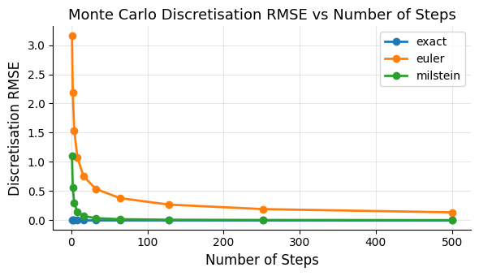

```python
mc_methods = [m for m in methods if m != 'analytical']
print("\n" + "=" * 80)
print("DISCRETIZATION ERROR ANALYTICS")
print("=" * 80)
pricer.discretization_error_analytics(mc_methods, n_steps_list, M)
```

Next we will demonstrate how to decrease MC error in all three numerical schemes. We focus on antithetic variance control method, repeat error analysis from the previous section and compare error results with and without variance reduction.

```
================================================================================
BASE OPTION PRICES
================================================================================

EUROPEAN Option Prices

╒════════════╤═══════════╕
│ Method     │     Price │
╞════════════╪═══════════╡
│ analytical │ 10.450584 │
├────────────┼───────────┤
│ exact      │ 10.400963 │
├────────────┼───────────┤
│ euler      │ 10.398138 │
├────────────┼───────────┤
│ milstein   │ 10.399177 │
╘════════════╧═══════════╛

BINARY Option Prices

╒════════════╤══════════╕
│ Method     │    Price │
╞════════════╪══════════╡
│ analytical │ 0.532325 │
├────────────┼──────────┤
│ exact      │ 0.528693 │
├────────────┼──────────┤
│ euler      │ 0.528123 │
├────────────┼──────────┤
│ milstein   │ 0.528693 │
╘════════════╧══════════╛

================================================================================
ERROR ANALYTICS
================================================================================

Monte Carlo VARIANCE -- EUROPEAN

╒══════╤════════════╤════════════╤════════════╕
│      │      exact │      euler │   milstein │
╞══════╪════════════╪════════════╪════════════╡
│  100 │ 1.17798840 │ 1.18009621 │ 1.17740251 │
├──────┼────────────┼────────────┼────────────┤
│  500 │ 0.21165511 │ 0.21032302 │ 0.21155200 │
├──────┼────────────┼────────────┼────────────┤
│ 1000 │ 0.08854011 │ 0.08832690 │ 0.08850066 │
├──────┼────────────┼────────────┼────────────┤
│ 5000 │ 0.01929043 │ 0.01921986 │ 0.01928151 │
╘══════╧════════════╧════════════╧════════════╛
```

[figure not shown]

```
Monte Carlo BIAS -- EUROPEAN

╒══════╤════════════╤════════════╤════════════╕
│      │      exact │      euler │   milstein │
╞══════╪════════════╪════════════╪════════════╡
│  100 │ 0.30111054 │ 0.30167439 │ 0.29922464 │
├──────┼────────────┼────────────┼────────────┤
│  500 │ 0.10021545 │ 0.10234777 │ 0.09838389 │
├──────┼────────────┼────────────┼────────────┤
│ 1000 │ 0.07096901 │ 0.07149126 │ 0.06914544 │
├──────┼────────────┼────────────┼────────────┤
│ 5000 │ 0.00807670 │ 0.00774029 │ 0.00626605 │
╘══════╧════════════╧════════════╧════════════╛
```

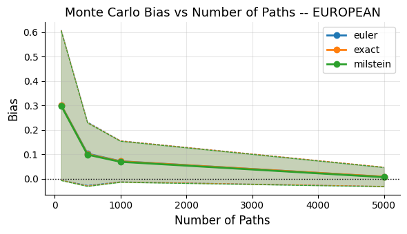

```
Monte Carlo VARIANCE -- BINARY

╒══════╤════════════╤════════════╤════════════╕
│      │      exact │      euler │   milstein │
╞══════╪════════════╪════════════╪════════════╡
│  100 │ 0.00052458 │ 0.00051350 │ 0.00052458 │
├──────┼────────────┼────────────┼────────────┤
│  500 │ 0.00007951 │ 0.00008061 │ 0.00007951 │
├──────┼────────────┼────────────┼────────────┤
│ 1000 │ 0.00003175 │ 0.00003413 │ 0.00003232 │
├──────┼────────────┼────────────┼────────────┤
│ 5000 │ 0.00000562 │ 0.00000674 │ 0.00000556 │
╘══════╧════════════╧════════════╧════════════╛
```

[figure not shown]

```
Monte Carlo BIAS -- BINARY

╒══════╤═════════════╤═════════════╤═════════════╕
│      │       exact │       euler │    milstein │
╞══════╪═════════════╪═════════════╪═════════════╡
│  100 │ -0.00229978 │ -0.00229978 │ -0.00229978 │
├──────┼─────────────┼─────────────┼─────────────┤
│  500 │ -0.00210953 │ -0.00176709 │ -0.00210953 │
├──────┼─────────────┼─────────────┼─────────────┤
│ 1000 │ -0.00119635 │ -0.00085391 │ -0.00115830 │
├──────┼─────────────┼─────────────┼─────────────┤
│ 5000 │ -0.00059898 │ -0.00050386 │ -0.00058757 │
╘══════╧═════════════╧═════════════╧═════════════╛
```

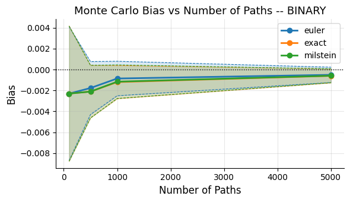

```
================================================================================
ANTITHETIC VARIANCE REDUCTION ANALYTICS
================================================================================
```

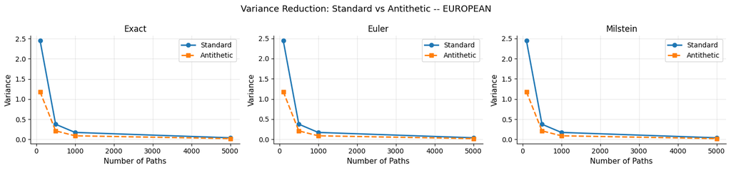

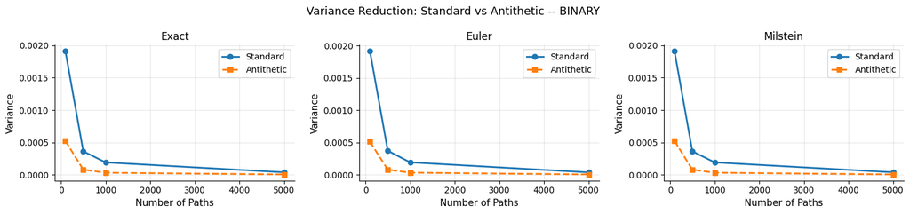

```python
# ── antithetic pricer ────────────────────────────────────────────────────
pricer_av = SimulationEngine(S, K, T, sigma, r, n_steps, n_paths, seed=seed, antithetic=True)

print("\n" + "=" * 80)
print("BASE OPTION PRICES")
print("=" * 80)
for option_type in option_types:
    pricer_av.produce_option_price_analytics(methods, option_type)

print("\n" + "=" * 80)
print("ERROR ANALYTICS")
print("=" * 80)
run_error_analytics(pricer_av, option_types, methods, n_paths_list, M)

# ── variance reduction comparison ────────────────────────────────────────
print("\n" + "=" * 80)
print("ANTITHETIC VARIANCE REDUCTION ANALYTICS")
print("=" * 80)
pricer.antithetic_variance_reduction_analytics(option_types, mc_methods, n_paths_list, M)
```

## 3. Observations

In this section we discuss key observations and challenges encountered during the exercise.

### 1. Numerical considerations

This exercise focused on vanilla path-independent options, for which the log-normal assumption yields closed-form stock prices at expiry. This made it straightforward to benchmark Monte Carlo results against both the analytical option price and the exact terminal distribution — a luxury that would not be available for path-dependent options, where only numerical approximations such as Euler-Maruyama or Milstein would apply.

Producing comparable results across methods requires careful simulation design. We share Brownian increments across Euler, Milstein, and the exact method within each experiment, so that differences in price estimates reflect only the discretisation scheme, not different noise realisations. However, increments must be regenerated when the number of paths or time steps changes — for instance, in the MC error and discretisation error analyses — and again for each of the $M$ independent replications used to estimate bias. Managing this consistently across a large number of experiments is a non-trivial engineering challenge, and any inconsistency risks introducing confounding noise into the comparisons.

A related point is that a single Monte Carlo price estimate is just that — a point estimate subject to sampling variability. Comparing methods on the basis of a single run without accompanying error analysis can be misleading, which is why we complemented each result with variance, bias, and confidence band diagnostics.

### 2. Sensitivity analysis

The European call behaves more smoothly: its Greeks do not change sign for the parameters considered, which reflects the convexity of its payoff. This stability makes local sensitivity analysis more reliable for European options than for binary ones, where a broader parameter sweep is needed to capture the full picture.

## 4. Summary

This exercise covered option pricing from first principles through to simulation and error analysis. We introduced two option types — European and binary calls — derived their closed-form prices and Greeks analytically, and implemented three simulation methods (Euler-Maruyama, Milstein, and the exact log-normal formula) within a structured Monte Carlo engine.

Sensitivity analysis confirmed that all four parameters — strike, volatility, time to expiry, and risk-free rate — move prices in directions consistent with the Greeks derived analytically. For European options the behaviour is monotone and sign-stable across moneyness, whereas binary options exhibit sign-switching Greeks that require a broader view to interpret correctly.

Overall, the exercise demonstrated how analytical and numerical methods complement each other in derivatives pricing: closed-form results provide benchmarks and intuition, while simulation methods extend the toolkit to settings where closed-form solutions are unavailable.

## 5. References

- [1] *Paul Wilmott introduces Quantitative Finance* by Paul Wilmott (2007).
- [2] *CQF lectures* by CQF Institute (2026)
- [3] *Milstein Note* by CQF Institute (2026)

### Appendix A

We will show SDE approximation workings to complement our introduction section

We start our derivations from general SDE solution:

$$ X_{t+\delta t} = X_{t} + \int_{t}^{t+\delta t} f(X_{s})ds + \int_{t}^{t+\delta t} g(X_{s})dW_{s} $$

Apply Ito's lemma around $X_{s}$: $$ g(X_{s}) = g(X_{t}) + g^{'}(X_{t})dX_{s} + \dots $$

$$ f(X_{s}) = f(X_{t}) + f^{'}(X_{t})dX_{s} + \dots $$

$$ dX_{s} = f(X_{s})ds + g(X_{s})dW_s $$

$$ \int_{t}^{t+\delta t} f(X_{s})ds = f(X_{t})\delta t + O(\delta t^{3/2}) $$

$$ \int_{t}^{t+\delta t} g(X_{s})dW_{s} = \int_{t}^{t+\delta t} (g(X_{t}) + g^{'}(X_{t})dX_{s}) dW_s + O(\delta t^{3/2}) = g(X_{t})(W_{t+\delta t} - W_{t}) + \int_{t}^{t+\delta t} g^{'}(X_{t})g(X_{s}) dW_{s}^2+ O(\delta t^{3/2}) = g(X_{t})\phi\sqrt{\delta t} + \int_{t}^{t+\delta t} g^{'}(X_{t})g(X_{t}) dW_{s}^2+ O(\delta t^{3/2}) = g(X_{t})\phi\sqrt{\delta t} + g^{'}(X_{t})g(X_{t})\int_{t}^{t+\delta t}dW_{s}^2+ O(\delta t^{3/2}) = g(X_{t})\phi\sqrt{\delta t} + g^{'}(X_{t})g(X_{t})\frac{1}{2}((W_{t+\delta t} - W_{t})^2 - \delta t ) + O(\delta t^{3/2}) = g(X_{t})\phi\sqrt{\delta t} + \frac{1}{2}g^{'}(X_{t})g(X_{t})(\phi^{2}- 1)\delta t $$

Substituting $f(X_{t}) = rX_{t}$ and $g(X_{t})=\sigma X_{t}$ gives Millstein approximation of SDE solution:

$$ X_{t+\delta t} = X_{t}(1+r\delta t + \sigma \phi\sqrt{\delta t} + \frac{1}{2}\sigma^{2} (\phi^{2}- 1)\delta t )+ O(\delta t^{3/2}) $$

In Euler approximation we use: $$ g(X_{s}) = g(X_{t}) + \dots $$

$$ f(X_{s}) = f(X_{t}) + \dots $$

which yields the result: $$ X_{t+\delta t} = X_{t}(1+r\delta t + \sigma \phi\sqrt{\delta t}) + O(\delta t^{3/2}) $$

In order to get exact formula apply Ito's lemma to function $log(X_{t})$: $$ dlog(X_{t}) = \frac{1}{X_{t}}dX_{t} - \frac{1}{2X_{t}^{2}}dX_{t}^{2} + O(\delta t^{3/2}) = \frac{1}{X_{t}}(rX_{t}dt + \sigma X_{t} dW_{t}) - \frac{1}{2X_{t}^{2}}(\sigma X_{t} dW_{t})^2 + O(\delta t^{3/2}) = rdt+\sigma dW_{t} - \frac{1}{2}\sigma^{2}dt + O(\delta t^{3/2}) = (r-\frac{1}{2}\sigma^{2})dt + \sigma dW_{t} + O(\delta t^{3/2}) $$

Integration of both sides gives: $$ \int_{t}^{T} dlog(X_{t}) = \int_{t}^{T} (r-\frac{1}{2}\sigma^{2})dt + \int_{t}^{T} \sigma dW_{t} $$

$$ log(X_{T}) = log(X_{t}) + (r-\frac{1}{2}\sigma^{2})(T-t) + \sigma (W_{T} - W_{t}) $$

$$ X_{T} = X_{t} exp( (r-\frac{1}{2}\sigma^{2})(T-t) + \sigma\phi\sqrt{T-t}) $$

### Appendix B

Here we present Greeks which are used in sensitivity results

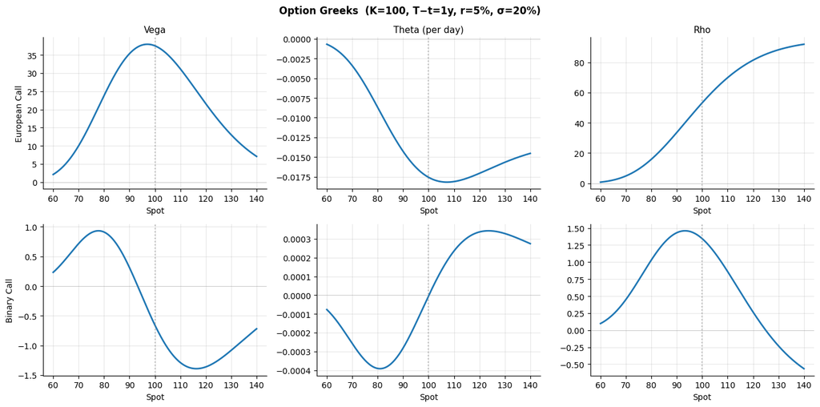

```python
def bs(S, K, tau, r, sigma):
    d1 = (np.log(S/K) + (r + 0.5*sigma**2)*tau) / (sigma*np.sqrt(tau))
    return d1, d1 - sigma*np.sqrt(tau)

def greeks(S, K, tau, r, sigma):
    d1, d2 = bs(S, K, tau, r, sigma)
    er = np.exp(-r*tau)
    nd1, nd2 = norm.pdf(d1), norm.pdf(d2)
    Nd2 = norm.cdf(d2)

    eu = [
        S * nd1 * np.sqrt(tau),                                                        # Vega
        (-S * norm.pdf(d1) * sigma / (2*np.sqrt(tau)) - r*K*er*Nd2) / 365,           # Theta
        K * tau * er * Nd2                                                              # Rho
    ]
    bi = [
        -er * nd2 * d1 / sigma,                                                        # Vega
        er * (r*Nd2 + nd2*(d1/(2*tau) - r/(sigma*np.sqrt(tau)))) / 365,               # Theta
        -tau * er * Nd2 + er * nd2 * np.sqrt(tau) / sigma                              # Rho
    ]
    return eu, bi

K, tau, r, sigma = 100, 1.0, 0.05, 0.2
S = np.linspace(60, 140, 300)
greek_labels = ['Vega', 'Theta (per day)', 'Rho']
eu, bi = greeks(S, K, tau, r, sigma)

fig, axes = plt.subplots(2, 3, figsize=(14, 7))
fig.suptitle("Option Greeks  (K=100, T−t=1y, r=5%, σ=20%)", fontsize=12, fontweight='bold')

for i, (data, title) in enumerate([(eu, 'European Call'), (bi, 'Binary Call')]):
    for j, (vals, lbl) in enumerate(zip(data, greek_labels)):
        ax = axes[i, j]
        ax.plot(S, vals, lw=2)
        ax.axvline(K, color='gray', ls=':', alpha=0.5)
        ax.axhline(0, color='gray', ls='-', lw=0.5, alpha=0.4)
        if i == 0: ax.set_title(lbl, fontsize=11)
        if j == 0: ax.set_ylabel(title, fontsize=10)
        ax.set_xlabel('Spot')
        ax.grid(alpha=0.3)

plt.tight_layout()
plt.show()
```

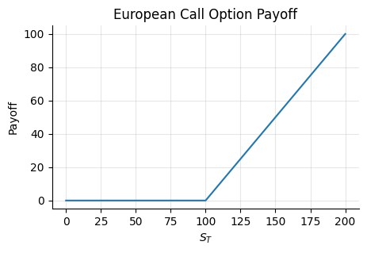

```python
K = 100
S_T = np.linspace(0, 200, 500)

call_payoff = np.maximum(S_T - K, 0)

plt.figure(figsize=(5, 3))
plt.plot(S_T, call_payoff)
plt.xlabel(r"$S_T$")
plt.ylabel("Payoff")
plt.title("European Call Option Payoff")
plt.grid(True)
plt.show()
```

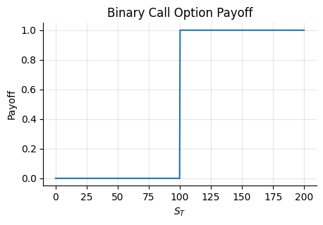

```python
binary_call = (S_T > K).astype(int)

plt.figure(figsize=(5, 3))
plt.plot(S_T, binary_call)
plt.xlabel(r"$S_T$")
plt.ylabel("Payoff")
plt.title("Binary Call Option Payoff")
plt.grid(True)
plt.show()
```